# Assignment 1: Data Preprocessing and EDA for E‑Commerce Orders

This notebook is your working template for **Assignment 1**.

You will:

- Load **four tables** (`orders`, `order_items`, `order_shipping`, `payments`).
- Join them into a single order-level dataset.
- Clean and transform the data.
- Perform basic EDA and visualization.

Work **top-to-bottom**. Complete each sub-part in the order they appear before proceeding.

## Submitted by

Group number on Canvas: 3

| Student ID (AxxxxxxxZ) | NUSNet ID (exxxxxxx) | Name (as it appears on Canvas) |
| --- | --- | --- |
| A0331401B | E1582257 | CHEN SITONG |
| A0319073E | E1520933 | LIANG MENGYING |
| A0326625A | E1538456 | LIN ZHANGXIN |
| A0328710J | E1553037 | SHI YANCHUN |

## Setup

Run the cell below to import the required Python packages.

```python
import numpy as np
import pandas as pd
import matplotlib.pyplot as plt
import sklearn
import seaborn as sns

plt.style.use('seaborn-v0_8')
```

```python
from google.colab import drive
drive.mount('/content/drive')

base_path = "/content/drive/MyDrive/IT5100F/"
```

## Part 1: Data Preprocessing (10 marks)

### 1.1 Data Loading & Joining (4 marks)

We first load each table, inspect it, and then join them into a single DataFrame.

#### Load the CSV files

**Task:**

- Dowload the four CSV files from canvas and upload them under the 'files' tab for this colab instance
- Load the four CSV files using `pd.read_csv()` into:
  - `df_orders`
  - `df_order_items`
  - `df_shipping`
  - `df_payments`

Update the filenames/paths if necessary.

```python
# ANSWER: load the CSV files
df_orders = pd.read_csv(base_path + "orders.csv")
df_order_items = pd.read_csv(base_path + "order_items.csv")
df_shipping = pd.read_csv(base_path + "order_shipping.csv")
df_payments = pd.read_csv(base_path + "payments.csv")
```

#### Inspect each table

**Task:**

- For **each** DataFrame, display:
  - `head()` (first 5 rows)
  - `shape` (rows, columns)

This helps you understand the raw structure before joining.

```python
# ANSWER: inspect the DataFrames
print("Orders Shape:", df_orders.shape)
display(df_orders.head())

print("Order Items Shape:", df_order_items.shape)
display(df_order_items.head())

print("Shipping Shape:", df_shipping.shape)
display(df_shipping.head())

print("Payments Shape:", df_payments.shape)
display(df_payments.head())
```

```
Orders Shape: (100000, 6)
```

|  | order_id | order_status | order_purchase_hour | order_purchase_dayofweek | order_purchase_month | order_total_value |
| --- | --- | --- | --- | --- | --- | --- |
| 0 | sdv-id-whzjUX | shipped | 10 | 4 | 4 | 744.312535 |
| 1 | sdv-id-gqShVM | delivered | 19 | 2 | 4 | 1030.521912 |
| 2 | sdv-id-vtaqcY | delivered | 18 | 4 | 8 | 28.472994 |
| 3 | sdv-id-xkqwdo | invoiced | 23 | 1 | 8 | 143.914263 |
| 4 | sdv-id-sGyHvQ | delivered | 19 | 0 | 2 | 16.944537 |

```
Order Items Shape: (100000, 8)
```

|  | order_id | num_items | num_unique_products | num_unique_sellers | total_item_price | avg_item_price | total_freight_value | top_product_category |
| --- | --- | --- | --- | --- | --- | --- | --- | --- |
| 0 | sdv-id-whzjUX | 1 | 1 | 1 | 352.420029 | 369.966521 | 68.790159 | construction_tools_construction |
| 1 | sdv-id-gqShVM | 1 | 1 | 1 | 1580.187928 | 1089.284136 | 84.603289 | auto |
| 2 | sdv-id-vtaqcY | 1 | 1 | 1 | 45.969263 | 36.969754 | 24.022637 | furniture_decor |
| 3 | sdv-id-xkqwdo | 1 | 1 | 1 | 146.023435 | 126.755360 | 16.945349 | consoles_games |
| 4 | sdv-id-sGyHvQ | 1 | 1 | 1 | 30.525812 | 22.797409 | 17.785846 | air_conditioning |

```
Shipping Shape: (100000, 2)
```

|  | order_id | customer_state |
| --- | --- | --- |
| 0 | sdv-id-whzjUX | Massachusetts |
| 1 | sdv-id-gqShVM | Ohio |
| 2 | sdv-id-vtaqcY | Wisconsin |
| 3 | sdv-id-xkqwdo | Michigan |
| 4 | sdv-id-sGyHvQ | Nevada |

```
Payments Shape: (100000, 2)
```

|  | order_id | payment_type |
| --- | --- | --- |
| 0 | sdv-id-whzjUX | voucher |
| 1 | sdv-id-gqShVM | voucher |
| 2 | sdv-id-vtaqcY | voucher |
| 3 | sdv-id-xkqwdo | credit_card |
| 4 | sdv-id-sGyHvQ | credit_card |

#### Join the tables on `order_id` to create a single order-level DataFrame

**Task:**

- Perform **inner joins** on `order_id` so that only orders present in **all** tables remain.
- Join order tables in this order:
  1. `df_orders` with `df_order_items`
  2. result with `df_shipping`
  3. result with `df_payments`
- Store the final DataFrame as `df_orders_full`.
- Display `head()` and `shape` for `df_orders_full`.

```python
# ANSWER: join the tables
df_merged_1 = pd.merge(df_orders, df_order_items, on='order_id', how='inner')
df_merged_2 = pd.merge(df_merged_1, df_shipping, on='order_id', how='inner')
df_orders_full = pd.merge(df_merged_2, df_payments, on='order_id', how='inner')

print("Final Joined Shape", df_orders_full.shape)
display(df_orders_full.head())
```

```
Final Joined Shape (100000, 15)
```

|  | order_id | order_status | order_purchase_hour | order_purchase_dayofweek | order_purchase_month | order_total_value | num_items | num_unique_products | num_unique_sellers | total_item_price | avg_item_price | total_freight_value | top_product_category | customer_state | payment_type |
| --- | --- | --- | --- | --- | --- | --- | --- | --- | --- | --- | --- | --- | --- | --- | --- |
| 0 | sdv-id-whzjUX | shipped | 10 | 4 | 4 | 744.312535 | 1 | 1 | 1 | 352.420029 | 369.966521 | 68.790159 | construction_tools_construction | Massachusetts | voucher |
| 1 | sdv-id-gqShVM | delivered | 19 | 2 | 4 | 1030.521912 | 1 | 1 | 1 | 1580.187928 | 1089.284136 | 84.603289 | auto | Ohio | voucher |
| 2 | sdv-id-vtaqcY | delivered | 18 | 4 | 8 | 28.472994 | 1 | 1 | 1 | 45.969263 | 36.969754 | 24.022637 | furniture_decor | Wisconsin | voucher |
| 3 | sdv-id-xkqwdo | invoiced | 23 | 1 | 8 | 143.914263 | 1 | 1 | 1 | 146.023435 | 126.755360 | 16.945349 | consoles_games | Michigan | credit_card |
| 4 | sdv-id-sGyHvQ | delivered | 19 | 0 | 2 | 16.944537 | 1 | 1 | 1 | 30.525812 | 22.797409 | 17.785846 | air_conditioning | Nevada | credit_card |

### 1.2 Data Cleaning (3 marks)

We now clean `df_orders_full` so it is ready for analysis.

#### Handle missing values

**Task:**

- For **numerical** columns: replace missing values with the **median** of that column.
- For **categorical** columns: replace missing values with the **mode** (most frequent value).
- Drop any rows where `order_id` or `payment_type` is missing (if any remain)

Work directly on `df_orders_full`.

```python
# ANSWER: Handle missing values
df_orders_full = df_orders_full.dropna(subset=["order_id"])

num_cols = df_orders_full.select_dtypes(include=["number"]).columns
cat_cols = df_orders_full.select_dtypes(exclude=["number"]).columns

for col in num_cols:
    df_orders_full[col] = df_orders_full[col].fillna(df_orders_full[col].median())
for col in cat_cols:
    if not df_orders_full[col].mode().empty:
        df_orders_full[col] = df_orders_full[col].fillna(df_orders_full[col].mode().iloc[0])

df_orders_full = df_orders_full.dropna(subset=["payment_type"])
```

#### Remove clearly invalid numeric records

**Task:**

- Remove rows where:
  - `num_items` ≤ 0, or
  - `order_total_value` ≤ 0, or
  - `total_item_price` < 0, or
  - `total_freight_value` < 0.

```python
# ANSWER: filter invalid numeric records
df_orders_full = df_orders_full[
    (df_orders_full["num_items"] > 0) &
    (df_orders_full["order_total_value"] > 0) &
    (df_orders_full["total_item_price"] >= 0) &
    (df_orders_full["total_freight_value"] >= 0)
]
```

#### Check cleanliness and key uniqueness

**Task:**

- Confirm there are **no null values** in `df_orders_full`.
- Check that `order_id` is unique (one row per order).

```python
# ANSWER: final cleaning checks
display(df_orders_full.isnull().sum())
df_orders_full["order_id"].is_unique
```

|  | 0 |
| --- | --- |
| order_id | 0 |
| order_status | 0 |
| order_purchase_hour | 0 |
| order_purchase_dayofweek | 0 |
| order_purchase_month | 0 |
| order_total_value | 0 |
| num_items | 0 |
| num_unique_products | 0 |
| num_unique_sellers | 0 |
| total_item_price | 0 |
| avg_item_price | 0 |
| total_freight_value | 0 |
| top_product_category | 0 |
| customer_state | 0 |
| payment_type | 0 |

**dtype:** int64

```
True
```

### 1.3 Data Transformation (3 marks)

Next, we perform sanity checks and create new features that will be useful later.

#### Sanity checks on counts and values

**Task:**

- Keep only rows where both:
  - `num_items` ≥ `num_unique_products`,
  - `order_total_value` ≥ `total_item_price + total_freight_value`

```python
# ANSWER: apply sanity checks
cond_items = df_orders_full["num_items"] >= df_orders_full["num_unique_products"]
cond_value = df_orders_full["order_total_value"] >= (df_orders_full["total_item_price"] + df_orders_full["total_freight_value"])

violations = (~cond_items) | (~cond_value)
print("Rows before sanity checks:", df_orders_full.shape[0])
print("Rows violating checks:", violations.sum())

df_orders_full = df_orders_full[cond_items & cond_value].copy()
print("Rows after sanity checks:", df_orders_full.shape[0])
```

```
Rows before sanity checks: 89175
Rows violating checks: 42888
Rows after sanity checks: 46287
```

#### Create `order_value_per_item`

**Task:**

- Create a new column `order_value_per_item` defined as `total_item_price / num_items`.

```python
# ANSWER: create order_value_per_item
df_orders_full["order_value_per_item"] = (
    df_orders_full["total_item_price"] / df_orders_full["num_items"]
)

df_orders_full[["total_item_price", "num_items", "order_value_per_item"]].head()
```

|  | total_item_price | num_items | order_value_per_item |
| --- | --- | --- | --- |
| 0 | 352.420029 | 1 | 352.420029 |
| 5 | 289.242639 | 1 | 289.242639 |
| 8 | 26.893468 | 1 | 26.893468 |
| 12 | 37.790896 | 1 | 37.790896 |
| 14 | 169.528323 | 3 | 56.509441 |

#### Create `order_size_category`

**Task:**

- Create a new categorical column `order_size_category` with values:
  - "Small" if `num_items` ≤ 2
  - "Medium" if `num_items` ≤ 5
  - "Large" if `num_items` > 5

```python
# ANSWER: create order_size_category
def categorize_order_size(n):
    if n <= 2:
        return "Small"
    elif n <= 5:
        return "Medium"
    else:
        return "Large"

df_orders_full["order_size_category"] = df_orders_full["num_items"].apply(categorize_order_size)

df_orders_full[["num_items", "order_size_category"]].head()
```

|  | num_items | order_size_category |
| --- | --- | --- |
| 0 | 1 | Small |
| 5 | 1 | Small |
| 8 | 1 | Small |
| 12 | 1 | Small |
| 14 | 3 | Medium |

#### Final transformation check

**Task:**

- Confirm there are no null values in `df_orders_full`.
- Display:
  - `head()`
  - `shape`
  - `info()`

```python
# ANSWER: final transformation summary
print("Total null values in df_orders_full:")
print(df_orders_full.isnull().sum())

display(df_orders_full.head())

print("Shape of df_orders_full:", df_orders_full.shape)

df_orders_full.info()
```

```
Total null values in df_orders_full:
order_id                    0
order_status                0
order_purchase_hour         0
order_purchase_dayofweek    0
order_purchase_month        0
order_total_value           0
num_items                   0
num_unique_products         0
num_unique_sellers          0
total_item_price            0
avg_item_price              0
total_freight_value         0
top_product_category        0
customer_state              0
payment_type                0
order_value_per_item        0
order_size_category         0
dtype: int64
```

|  | order_id | order_status | order_purchase_hour | order_purchase_dayofweek | order_purchase_month | order_total_value | num_items | num_unique_products | num_unique_sellers | total_item_price | avg_item_price | total_freight_value | top_product_category | customer_state | payment_type | order_value_per_item | order_size_category |
| --- | --- | --- | --- | --- | --- | --- | --- | --- | --- | --- | --- | --- | --- | --- | --- | --- | --- |
| 0 | sdv-id-whzjUX | shipped | 10 | 4 | 4 | 744.312535 | 1 | 1 | 1 | 352.420029 | 369.966521 | 68.790159 | construction_tools_construction | Massachusetts | voucher | 352.420029 | Small |
| 5 | sdv-id-dbopoJ | delivered | 19 | 2 | 3 | 1556.667902 | 1 | 1 | 1 | 289.242639 | 1354.621410 | 15.394619 | health_beauty | Vermont | credit_card | 289.242639 | Small |
| 8 | sdv-id-FSEOvM | delivered | 15 | 4 | 8 | 62.060506 | 1 | 1 | 1 | 26.893468 | 48.485654 | 18.751282 | luggage_accessories | South Carolina | debit_card | 26.893468 | Small |
| 12 | sdv-id-bQcBUR | delivered | 21 | 0 | 8 | 73.873470 | 1 | 1 | 1 | 37.790896 | 75.704909 | 8.670875 | computers_accessories | Kentucky | credit_card | 37.790896 | Small |
| 14 | sdv-id-MPxIXB | delivered | 13 | 5 | 5 | 361.961537 | 3 | 3 | 3 | 169.528323 | 50.132979 | 34.731146 | pet_shop | Missouri | voucher | 56.509441 | Medium |

```
Shape of df_orders_full: (46287, 17)
<class 'pandas.core.frame.DataFrame'>
Index: 46287 entries, 0 to 99997
Data columns (total 17 columns):
 #   Column                    Non-Null Count  Dtype
---  ------                    --------------  -----
 0   order_id                  46287 non-null  object
 1   order_status              46287 non-null  object
 2   order_purchase_hour       46287 non-null  int64
 3   order_purchase_dayofweek  46287 non-null  int64
 4   order_purchase_month      46287 non-null  int64
 5   order_total_value         46287 non-null  float64
 6   num_items                 46287 non-null  int64
 7   num_unique_products       46287 non-null  int64
 8   num_unique_sellers        46287 non-null  int64
 9   total_item_price          46287 non-null  float64
 10  avg_item_price            46287 non-null  float64
 11  total_freight_value       46287 non-null  float64
 12  top_product_category      46287 non-null  object
 13  customer_state            46287 non-null  object
 14  payment_type              46287 non-null  object
 15  order_value_per_item      46287 non-null  float64
 16  order_size_category       46287 non-null  object
dtypes: float64(5), int64(6), object(6)
memory usage: 6.4+ MB
```

### 1.4 Data Storage

We now save the cleaned, joined, and transformed dataset.

#### 1.4A Save cleaned dataset

**Task:**

- Save `df_orders_full` as `ecommerce_orders_cleaned.csv` (without the index).

```python
# ANSWER: save to CSV
df_orders_full.to_csv("ecommerce_orders_cleaned.csv", index=False)

print("Saved file: ecommerce_orders_cleaned.csv")
```

```
Saved file: ecommerce_orders_cleaned.csv
```

## Part 2: EDA & Data Visualization (4 marks)

We now reload the cleaned dataset and explore it.

### 2.0 Load Transformed Dataset

#### 2.0 Reload CSV

**Task:**

- Load `ecommerce_orders_cleaned.csv` into `df_orders_cleaned`.
- Display `head()` and `shape`.

```python
# ANSWER: load cleaned dataset
df_orders_cleaned = pd.read_csv("ecommerce_orders_cleaned.csv")

display(df_orders_cleaned.head())
print("Shape of df_orders_cleaned:", df_orders_cleaned.shape)
```

|  | order_id | order_status | order_purchase_hour | order_purchase_dayofweek | order_purchase_month | order_total_value | num_items | num_unique_products | num_unique_sellers | total_item_price | avg_item_price | total_freight_value | top_product_category | customer_state | payment_type | order_value_per_item | order_size_category |
| --- | --- | --- | --- | --- | --- | --- | --- | --- | --- | --- | --- | --- | --- | --- | --- | --- | --- |
| 0 | sdv-id-whzjUX | shipped | 10 | 4 | 4 | 744.312535 | 1 | 1 | 1 | 352.420029 | 369.966521 | 68.790159 | construction_tools_construction | Massachusetts | voucher | 352.420029 | Small |
| 1 | sdv-id-dbopoJ | delivered | 19 | 2 | 3 | 1556.667902 | 1 | 1 | 1 | 289.242639 | 1354.621410 | 15.394619 | health_beauty | Vermont | credit_card | 289.242639 | Small |
| 2 | sdv-id-FSEOvM | delivered | 15 | 4 | 8 | 62.060506 | 1 | 1 | 1 | 26.893468 | 48.485654 | 18.751282 | luggage_accessories | South Carolina | debit_card | 26.893468 | Small |
| 3 | sdv-id-bQcBUR | delivered | 21 | 0 | 8 | 73.873470 | 1 | 1 | 1 | 37.790896 | 75.704909 | 8.670875 | computers_accessories | Kentucky | credit_card | 37.790896 | Small |
| 4 | sdv-id-MPxIXB | delivered | 13 | 5 | 5 | 361.961537 | 3 | 3 | 3 | 169.528323 | 50.132979 | 34.731146 | pet_shop | Missouri | voucher | 56.509441 | Medium |

```
Shape of df_orders_cleaned: (46287, 17)
```

### 2.1 Unique Categories and Payment Types (1 mark)

**Task:**

- Compute the number of unique values in `top_product_category` and `payment_type`.
- Display:
  - The top 5 product categories by order count.
  - The top 3 payment types by order count.

```python
# ANSWER: unique counts and top values
print("Unique product categories:",df_orders_cleaned["top_product_category"].nunique())

print("Unique payment types:",df_orders_cleaned["payment_type"].nunique())

top5_categories = (df_orders_cleaned["top_product_category"].value_counts().head(5))
print(top5_categories)

top3_payments = (df_orders_cleaned["payment_type"].value_counts().head(3))
print(top3_payments)
```

```
Unique product categories: 71
Unique payment types: 5
top_product_category
bed_bath_table           6419
health_beauty            4208
furniture_decor          3413
computers_accessories    3386
telephony                2570
Name: count, dtype: int64
payment_type
credit_card    27987
voucher        13812
points          2532
Name: count, dtype: int64
```

### 2.2 Bar Chart of Orders by Product Category (2 marks)

#### Create bar chart

**Task:**

- Create a bar chart of number of orders per `top_product_category`, sorted in descending order.
- Add a clear title and axis labels.

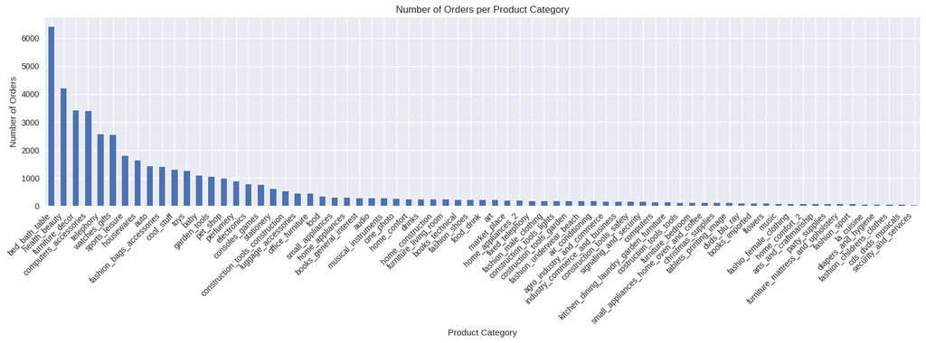

```python
# ANSWER: bar chart of product categories
category_counts = df_orders_cleaned["top_product_category"].value_counts()

plt.figure(figsize=(16,6))

category_counts.plot(kind="bar")

plt.title("Number of Orders per Product Category")
plt.xlabel("Product Category")
plt.ylabel("Number of Orders")

plt.xticks(rotation=45, ha="right")
plt.tight_layout()

plt.show()
```

#### Brief interpretation

**Task:**

- In 2–3 sentences, describe any trends you see (e.g., which categories dominate, whether the distribution is skewed, etc.).

The bar chart shows a highly skewed distribution of orders across product categories. A few categories such as bed_bath_table and health_beauty dominate the total number of orders, while most other categories have significantly fewer orders. This indicates that customer demand is concentrated in a small number of product segments.

### 2.3 Box Plot: Order Value vs Number of Items (2 mark)

#### Create box plot

**Task:**

- Create a box plot with:
  - X‑axis: `num_items`
  - Y‑axis: `order_total_value`
- Add a clear title and axis labels.

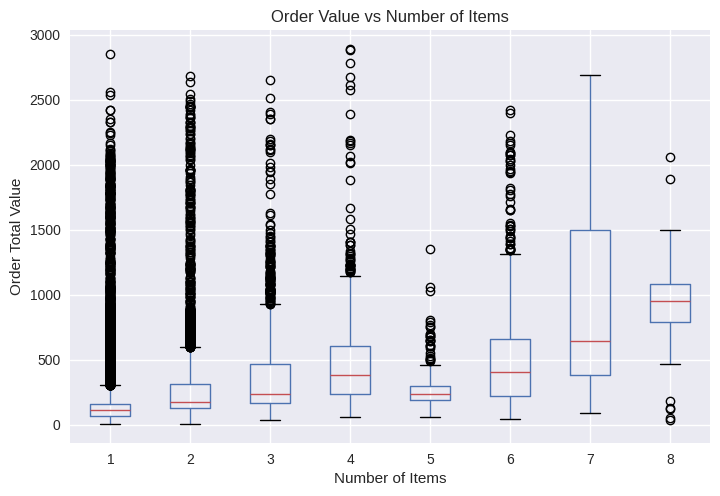

```python
# ANSWER: box plot order_total_value vs num_items
plt.figure(figsize=(16,10))

df_orders_cleaned.boxplot(column="order_total_value",by="num_items")

plt.title("Order Value vs Number of Items")
plt.xlabel("Number of Items")
plt.ylabel("Order Total Value")

plt.suptitle("")
plt.show()
```

#### Brief interpretation

**Task:**

- In 2–3 sentences, describe how order value changes as the number of items increases (e.g., linear trend, diminishing returns, many outliers, etc.).

Order total value generally increases with the number of items, but the trend is not strictly linear and shows signs of diminishing returns at certain item counts. A clearer increase in order value is observed when orders contain more than seven items, suggesting customers tend to spend more when buying in bulk. Numerous outliers indicate occasional high-value transactions.